# Influência da confiabilidade e do tempo de viagem no número de passageiros MG transportados pelo transporte público coletivo: um estudo para Belo Horizonte

Ramon Batista, Guilherme Grochowski, Leise Kelli de Oliveira, Luís Otávio Rocha Castilho, Marlon José Soares

11/05/2021

## R Markdown

Os serviços públicos de transporte coletivo por ônibus das grandes cidades brasileiras vêm apresentando queda no número de passageiros, enquanto o número de viagens realizadas por meios individuais motorizadas estão em ascensão no paradigma recente das grandes cidades brasileiras. A busca pela reversão deste quadro passa pela melhoria dos serviços prestados aos usuários do transporte público coletivo por ônibus, sendo esta melhoria diretamente relacionada à confiabilidade do serviço. Neste sentido, o objetivo deste trabalho é apontar relações estatísticas entre a confiabilidade e o tempo de viagem e o número de passageiros transportados no serviço de ônibus na cidade de Belo Horizonte - MG, entre os anos de 2014 e 2019, por meio do tratamento de dados através do software R.

```r
library('readxl') #ler excel
library('dplyr') #Manipulação
library('lubridate') #datas
library('ggplot2')
library('gridExtra')
library('corrplot')
library('MASS')
```

```r
#Importando os dados
df <- read_excel('BD_Pont.xlsx')

#Visualizando a estrutura dos dados
str(df)
```

```
## tibble [150,621 x 13] (S3: tbl_df/tbl/data.frame)
##  $ Ano                        : num [1:150621] 2017 2018 2019 2019 2019 ...
##  $ Concessionária             : num [1:150621] 803 803 803 803 803 803 803 803 803 803 ...
##  $ Linha                      : num [1:150621] 101 101 101 101 101 101 101 101 101 101 ...
##  $ Especificada               : chr [1:150621] ":" ":" ":" ":" ...
##  $ Especificada Tolerância    : chr [1:150621] ":" ":" ":" ":" ...
##  $ Especificada Posterior     : chr [1:150621] ":" ":" ":" ":" ...
##  $ Hora Realizada Pontualidade: POSIXct[1:150621], format: "1899-12-31 19:24:00" "1899-12-31 18:05:00" ...
##  $ Conc                       : chr [1:150621] "101-0,808333333333333" "101-0,753472222222222" "101-0,750694444444444" "101-0,800694444444444" ...
##  $ Minutos Atraso Pontualidade: num [1:150621] 0 0 0 0 0 1 4 1 1 1 ...
##  $ ATRASO                     : chr [1:150621] "N" "N" "N" "N" ...
##  $ ATRASO 0/1                 : num [1:150621] 0 0 0 0 0 0 0 0 0 0 ...
##  $ Demanda                    : num [1:150621] 47518 3473 34643 44033 44074 ...
##  $ TP VG                      : POSIXct[1:150621], format: "1899-12-31 00:44:00" "1899-12-31 01:04:00" ...
```

```r
#Explorando as variáveis
summary(df)
```

```
##       Ano       Concessionária      Linha       Especificada
##  Min.   :2014   Min.   :801.0   Min.   :  30    Length:150621
##  1st Qu.:2015   1st Qu.:801.0   1st Qu.: 614    Class :character
##  Median :2016   Median :802.0   Median :2102    Mode  :character
##  Mean   :2016   Mean   :802.3   Mean   :3624
##  3rd Qu.:2018   3rd Qu.:803.0   3rd Qu.:8103
##  Max.   :2019   Max.   :804.0   Max.   :9850
##                                 NA's   :21748
##  Especificada Tolerância Especificada Posterior Hora Realizada Pontualidade
##  Length:150621           Length:150621          Min.   :1899-12-31 00:00:00
##  Class :character        Class :character       1st Qu.:1899-12-31 07:51:00
##  Mode  :character        Mode  :character       Median :1899-12-31 12:59:00
##                                                 Mean   :1899-12-31 12:54:24
##                                                 3rd Qu.:1899-12-31 17:27:00
##                                                 Max.   :1899-12-31 23:52:00
##
##      Conc           Minutos Atraso Pontualidade    ATRASO
##  Length:150621      Min.   : 0.000              Length:150621
##  Class :character   1st Qu.: 0.000              Class :character
##  Mode  :character   Median : 1.000              Mode  :character
##                     Mean   : 1.609
##                     3rd Qu.: 2.000
##                     Max.   :68.000
##
##    ATRASO 0/1         Demanda          TP VG
##  Min.   :0.00000   Min.   :    0   Min.   :1899-12-31 00:00:00
##  1st Qu.:0.00000   1st Qu.:17315   1st Qu.:1899-12-31 00:42:00
##  Median :0.00000   Median :42328   Median :1899-12-31 00:59:00
##  Mean   :0.02538   Mean   :44328   Mean   :1899-12-31 01:03:12
##  3rd Qu.:0.00000   3rd Qu.:70098   3rd Qu.:1899-12-31 01:19:00
##  Max.   :1.00000   Max.   :99999   Max.   :1899-12-31 11:27:00
##                    NA's   :6       NA's   :6
```

```r
#Selecionando as variáveis
df <- df[c('Demanda', 'Minutos Atraso Pontualidade', 'TP VG')]
head(df)
```

```
## # A tibble: 6 x 3
##   Demanda `Minutos Atraso Pontualidade` `TP VG`
##     <dbl>                         <dbl> <dttm>
## 1   47518                             0 1899-12-31 00:44:00
## 2    3473                             0 1899-12-31 01:04:00
## 3   34643                             0 1899-12-31 01:08:00
## 4   44033                             0 1899-12-31 00:49:00
## 5   44074                             0 1899-12-31 00:50:00
## 6   19718                             1 1899-12-31 00:37:00
```

```r
#Renomeando Colunas
df <- rename(df, demanda = Demanda, atraso = `Minutos Atraso Pontualidade`, tempo = `TP VG`)
df
```

```
## # A tibble: 150,621 x 3
##    demanda atraso tempo
##      <dbl>  <dbl> <dttm>
##  1   47518      0 1899-12-31 00:44:00
##  2    3473      0 1899-12-31 01:04:00
##  3   34643      0 1899-12-31 01:08:00
##  4   44033      0 1899-12-31 00:49:00
##  5   44074      0 1899-12-31 00:50:00
##  6   19718      1 1899-12-31 00:37:00
##  7    1291      4 1899-12-31 00:33:00
##  8    6815      1 1899-12-31 00:41:00
##  9    6815      1 1899-12-31 00:41:00
## 10    6815      1 1899-12-31 00:41:00
## # ... with 150,611 more rows
```

```r
#Verificando valores nulos
sum(is.na(df))
```

```
## [1] 12
```

```r
df <- na.omit(df)  #Removendo valores na
sum(is.na(df))
```

```
## [1] 0
```

```r
#Converter tempo para minutos
t <- ymd_hms(df$tempo)
df$tempo <- (hour(t)*60 + minute(t)+ second(t)/360)
head(df)
```

```
## # A tibble: 6 x 3
##   demanda atraso tempo
##     <dbl>  <dbl> <dbl>
## 1   47518      0    44
## 2    3473      0    64
## 3   34643      0    68
## 4   44033      0    49
## 5   44074      0    50
## 6   19718      1    37
```

```r
summary(df)
```

```
##     demanda          atraso           tempo
##  Min.   :    0   Min.   : 0.000   Min.   :  0.0
##  1st Qu.:17315   1st Qu.: 0.000   1st Qu.: 42.0
##  Median :42328   Median : 1.000   Median : 59.0
##  Mean   :44328   Mean   : 1.609   Mean   : 63.2
##  3rd Qu.:70098   3rd Qu.: 2.000   3rd Qu.: 79.0
##  Max.   :99999   Max.   :68.000   Max.   :687.0
```

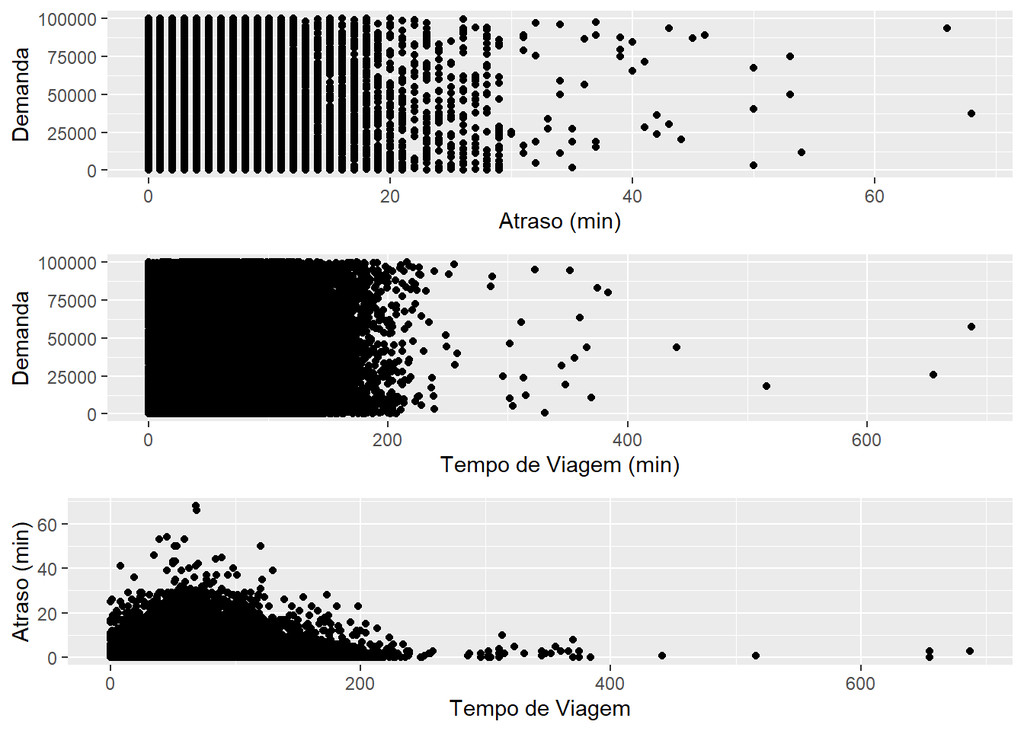

```r
#Criando Gráficos
g1 <- ggplot(df, aes(y = demanda, x = atraso)) +
  geom_point() +
  xlab("Atraso (min)") +
  ylab("Demanda")

g2 <- ggplot(df, aes(y = demanda, x = tempo)) +
  geom_point() +
  xlab("Tempo de Viagem (min)") +
  ylab("Demanda")

g3 <-ggplot(df, aes(y = atraso, x = tempo)) +
  geom_point() +
  xlab("Tempo de Viagem") +
  ylab("Atraso (min)")

grid.arrange(g1, g2, g3)
```

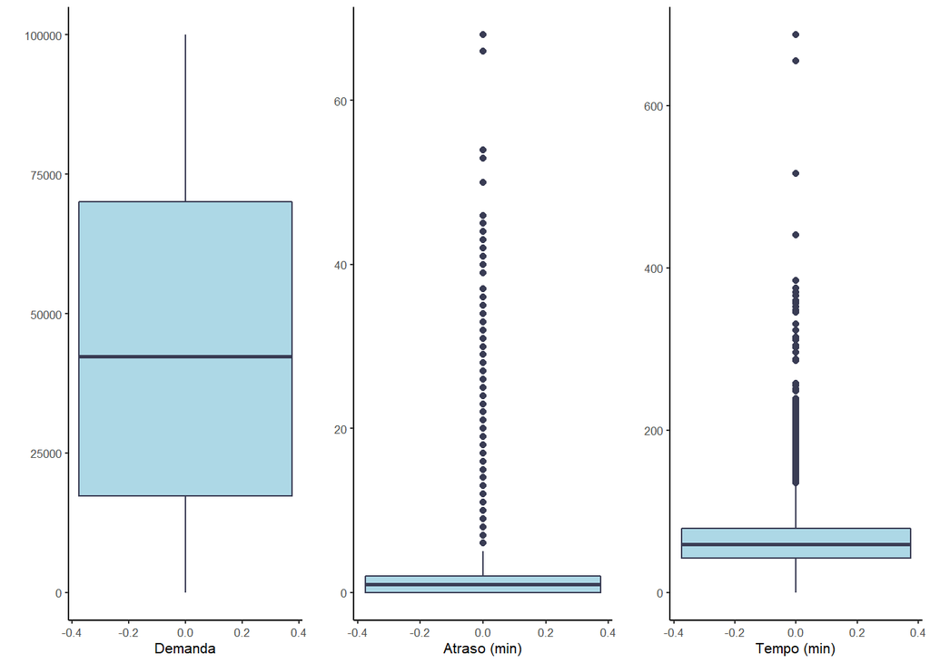

```r
g4 <- ggplot(df, aes(y = demanda)) +
  geom_boxplot(color = "#393c54", fill = "lightblue") +
  theme_classic(base_size = 8)+
  xlab("Demanda")+
  ylab("")

g5 <- ggplot(df, aes(y = atraso)) +
  geom_boxplot(color = "#393c54", fill = "lightblue") +
  theme_classic(base_size = 8)+
  xlab("Atraso (min)")+
  ylab("")

g6 <- ggplot(df, aes(y = tempo)) +
  geom_boxplot(color = "#393c54", fill = "lightblue")  +
  theme_classic(base_size = 8)+
  xlab("Tempo (min)")+
  ylab("")

grid.arrange(g4, g5, g6, ncol=3)
```

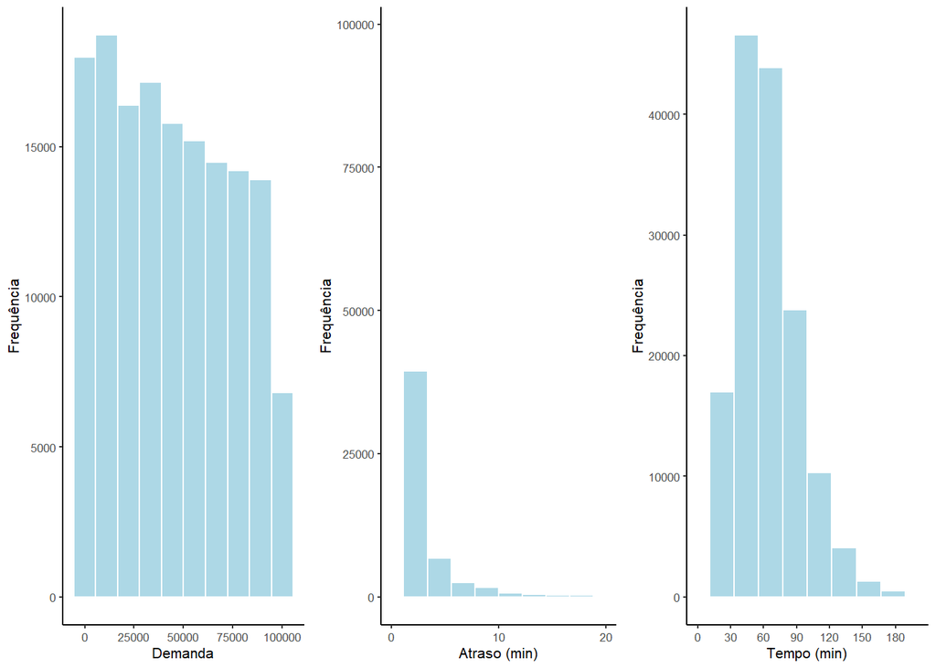

```r
g7 <- ggplot(df, aes(x = demanda)) +
  geom_histogram(color = "white", fill = "lightblue", bins=10)  +
  theme_classic(base_size = 8)+
  xlab("Demanda")+
  ylab("Frequência")

g8 <- ggplot(df, aes(x = atraso)) +
  geom_histogram(color = "white", fill = "lightblue", bins=10) +
  theme_classic(base_size = 8)+
  scale_x_continuous(breaks = seq(from = 0,to = 20,by = 10), limits = c(0,20)) +
  xlab("Atraso (min)")+
  ylab("Frequência")


g9 <- ggplot(df, aes(x = tempo)) +
  geom_histogram(color = "white", fill = "lightblue", bins=10) +
  theme_classic(base_size = 8)+
  scale_x_continuous(breaks = seq(from = 0,to = 200,by = 30), limits = c(0,200))+
  xlab("Tempo (min)")+
  ylab("Frequência")

grid.arrange(g7, g8, g9, ncol=3)
```

```r
#Eliminando Outliers
outliers <- boxplot(df$atraso, plot=FALSE)$out
df <- df[-which(df$atraso %in% outliers),]

outliers <- boxplot(df$tempo, plot=FALSE)$out
df <- df[-which(df$tempo %in% outliers),]
```

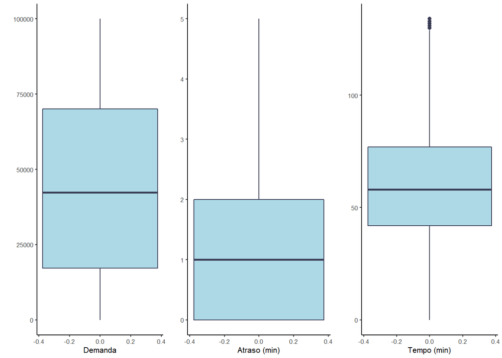

```r
#Repetindo gráficos
g4 <- ggplot(df, aes(y = demanda)) +
  geom_boxplot(color = "#393c54", fill = "lightblue") +
  theme_classic(base_size = 8)+
  xlab("Demanda")+
  ylab("")

g5 <- ggplot(df, aes(y = atraso)) +
  geom_boxplot(color = "#393c54", fill = "lightblue") +
  theme_classic(base_size = 8)+
  xlab("Atraso (min)")+
  ylab("")

g6 <- ggplot(df, aes(y = tempo)) +
  geom_boxplot(color = "#393c54", fill = "lightblue")  +
  theme_classic(base_size = 8)+
  xlab("Tempo (min)")+
  ylab("")

grid.arrange(g4, g5, g6, ncol=3)
```

```r
#Summary
summary(df)
```

```
##     demanda          atraso          tempo
##  Min.   :    0   Min.   :0.000   Min.   :  0.00
##  1st Qu.:17198   1st Qu.:0.000   1st Qu.: 42.00
##  Median :42279   Median :1.000   Median : 58.00
##  Mean   :44277   Mean   :1.225   Mean   : 60.86
##  3rd Qu.:70081   3rd Qu.:2.000   3rd Qu.: 77.00
##  Max.   :99999   Max.   :5.000   Max.   :134.00
```

```r
#Correlações
cor.df <- cor(df, method = "spearman")
cor(df)
```

```
##            demanda      atraso       tempo
## demanda 1.00000000  0.06106754  0.01408736
## atraso  0.06106754  1.00000000 -0.02832207
## tempo   0.01408736 -0.02832207  1.00000000
```

Nota-se que os valores são próximos de 0, não existindo correlações estatísticas entre as variáveis.

```r
#Regressão
modelo1 <- lm(df$atraso~df$demanda)
summary(modelo1)
```

```
##
## Call:
## lm(formula = df$atraso ~ df$demanda)
##
## Residuals:
##     Min      1Q  Median      3Q     Max
## -1.3522 -1.1248 -0.2134  0.7408  3.8752
##
## Coefficients:
##              Estimate Std. Error t value Pr(>|t|)
## (Intercept) 1.125e+00  5.303e-03  212.09   <2e-16 ***
## df$demanda  2.274e-06  9.899e-08   22.98   <2e-16 ***
## ---
## Signif. codes:  0 '***' 0.001 '**' 0.01 '*' 0.05 '.' 0.1 ' ' 1
##
## Residual standard error: 1.121 on 141029 degrees of freedom
## Multiple R-squared:  0.003729,   Adjusted R-squared:  0.003722
## F-statistic: 527.9 on 1 and 141029 DF,  p-value: < 2.2e-16
```

```r
modelo2 <- lm(df$tempo~df$demanda)
summary(modelo2)
```

```
##
## Call:
## lm(formula = df$tempo ~ df$demanda)
##
## Residuals:
##     Min      1Q  Median      3Q     Max
## -61.549 -19.028  -2.443  16.537  73.678
##
## Coefficients:
##              Estimate Std. Error t value Pr(>|t|)
## (Intercept) 6.032e+01  1.250e-01 482.394  < 2e-16 ***
## df$demanda  1.235e-05  2.334e-06   5.291 1.22e-07 ***
## ---
## Signif. codes:  0 '***' 0.001 '**' 0.01 '*' 0.05 '.' 0.1 ' ' 1
##
## Residual standard error: 26.44 on 141029 degrees of freedom
## Multiple R-squared:  0.0001985,  Adjusted R-squared:  0.0001914
## F-statistic: 27.99 on 1 and 141029 DF,  p-value: 1.219e-07
```

```r
modelo3 <- lm(df$atraso~df$tempo)
summary(modelo3)
```

```
##
## Call:
## lm(formula = df$atraso ~ df$tempo)
##
## Residuals:
##     Min      1Q  Median      3Q     Max
## -1.2987 -1.1808 -0.2241  0.7578  3.8625
##
## Coefficients:
##               Estimate Std. Error t value Pr(>|t|)
## (Intercept)  1.2987255  0.0075050  173.05   <2e-16 ***
## df$tempo    -0.0012034  0.0001131  -10.64   <2e-16 ***
## ---
## Signif. codes:  0 '***' 0.001 '**' 0.01 '*' 0.05 '.' 0.1 ' ' 1
##
## Residual standard error: 1.123 on 141029 degrees of freedom
## Multiple R-squared:  0.0008021,  Adjusted R-squared:  0.0007951
## F-statistic: 113.2 on 1 and 141029 DF,  p-value: < 2.2e-16
```

```r
#Teste T
t.test(df$atraso,df$demanda)
```

```
##
##  Welch Two Sample t-test
##
## data:  df$atraso and df$demanda
## t = -551.25, df = 141030, p-value < 2.2e-16
## alternative hypothesis: true difference in means is not equal to 0
## 95 percent confidence interval:
##  -44433.47 -44118.63
## sample estimates:
##    mean of x    mean of y
##     1.225482 44277.274819
```

```r
t.test(df$tempo,df$demanda)
```

```
##
##  Welch Two Sample t-test
##
## data:  df$tempo and df$demanda
## t = -550.51, df = 141030, p-value < 2.2e-16
## alternative hypothesis: true difference in means is not equal to 0
## 95 percent confidence interval:
##  -44373.84 -44058.99
## sample estimates:
##   mean of x   mean of y
##    60.86287 44277.27482
```

```r
t.test(df$atraso,df$tempo)
```

```
##
##  Welch Two Sample t-test
##
## data:  df$atraso and df$tempo
## t = -846.33, df = 141539, p-value < 2.2e-16
## alternative hypothesis: true difference in means is not equal to 0
## 95 percent confidence interval:
##  -59.77550 -59.49928
## sample estimates:
## mean of x mean of y
##  1.225482 60.862874
```

```r
#IC
confint(modelo1, level=0.95)
```

```
##                    2.5 %       97.5 %
## (Intercept) 1.114384e+00 1.135173e+00
## df$demanda  2.080379e-06 2.468416e-06
```

```r
confint(modelo2, level=0.95)
```

```
##                    2.5 %       97.5 %
## (Intercept) 6.007107e+01 6.056121e+01
## df$demanda  7.773725e-06 1.692225e-05
```

```r
confint(modelo3, level=0.95)
```

```
##                    2.5 %        97.5 %
## (Intercept)  1.284015842  1.3134351100
## df$tempo    -0.001425085 -0.0009817393
```

H0 = Dependência entre as variáveis H1 = Hipotese alternativa α = 0,05

```r
#Teste Qui-Quadrado
chisq.test(df)
```

```
##
##  Pearson's Chi-squared test
##
## data:  df
## X-squared = NaN, df = 282060, p-value = NA
```

```r
chisq.test(df$atraso,df$demanda)
```

```
##
##  Pearson's Chi-squared test
##
## data:  df$atraso and df$demanda
## X-squared = 416387, df = 277280, p-value < 2.2e-16
```

```r
chisq.test(df$tempo,df$demanda)
```

```
##
##  Pearson's Chi-squared test
##
## data:  df$tempo and df$demanda
## X-squared = 12584314, df = 7431104, p-value < 2.2e-16
```

```r
chisq.test(df$atraso,df$tempo)
```

```
##
##  Pearson's Chi-squared test
##
## data:  df$atraso and df$tempo
## X-squared = 2133.9, df = 670, p-value < 2.2e-16
```